# 建模基础

# 目录

- 1 介绍
  - 1.1 前提准备
- 2 简单模型
  - 2.1 可视化MSE
  - 2.2 最优化函数 `optim()`
  - 2.3 线性回归函数 `lm()`
- 3 模型可视化
  - 3.1 预测
  - 3.2 残差
- 4 公式和模型族
  - 4.1 类别变量
  - 4.2 交互作用（连续变量和类别变量）
  - 4.3 交互作用（两个连续变量）
  - 4.4 数据转换
- 5 缺失值
- 6 其他模型族

# 1 介绍

模型的作用在于对数据集进行低维度的总结，使用模型将数据集划分为模式和残差。一个模型包括两个方面：

- **family of models**：代表你想要捕捉的模式，例如线性模型、二次多项式模型等等
- **fitted model**：从模型族中拟合出最接近数据集的模型

需要注意的是，拟合出的模型只是模型族中最接近数据集的模型。这意味着，拟合出的模型并不一定是好的或正确的模型。这一思想可以用以下名言表达：

> All models are wrong, but some are useful.

## 1.1 前提准备

```r
library(tidyverse)
```

```r
library(modelr)
options(na.action = na.warn)
```

# 2 简单模型

观察一个包含变量 `x` 、 `y` 的模拟数据集 `sim1` ：

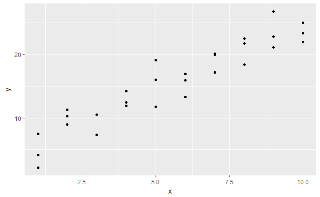

```r
ggplot(sim1, aes(x, y)) +
  geom_point()
```

从散点图看出， `x` 与 `y` 大致是线性关系 `y = a_0 + a_1 * x` 。在散点图中随机生成250条直线，每条线都代表一个线性模型，找出拟合程度最高的模型：

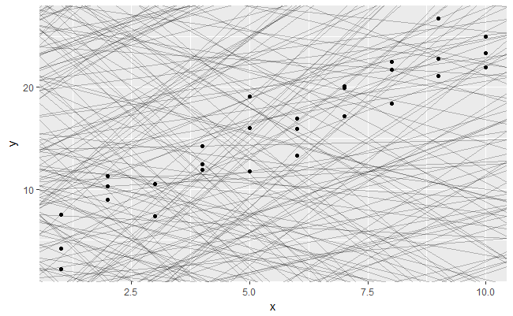

```r
models <- tibble(
  a1 = runif(250, -20, 40),
  a2 = runif(250, -5, 5)
)
ggplot(sim1, aes(x, y)) +
  geom_abline(aes(intercept = a1, slope = a2), data = models, alpha = 1/4) +
  geom_point()
```

用直线与数据点的垂直距离来衡量模型对数据的拟合程度：

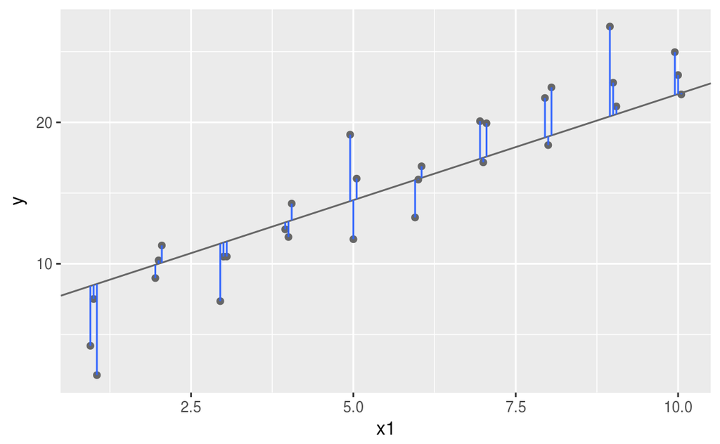

## 2.1 可视化MSE

- 输入模型参数，输出预测值

```r
model1 <- function(a, data) {
  a[1] + data$x * a[2]
}
model1(c(7, 1.5), sim1)
```

```
 [1]  8.5  8.5  8.5 10.0 10.0 10.0 11.5 11.5 11.5 13.0 13.0 13.0 14.5 14.5 14.5 16.0 16.0 16.0 17.5 17.5 17.5 19.0 19.0
[24] 19.0 20.5 20.5 20.5 22.0 22.0 22.0
```

- 输入模型参数，输出模型与数据点的距离（均方误差）

```r
measure_distance <- function(mod, data) {
  diff <- data$y - model1(mod, data)
  sqrt(mean(diff ^ 2))
}
measure_distance(c(7, 1.5), sim1)
```

```
[1] 2.665212
```

- 用 `purrr::map2_dbl` 组合以上函数，批量计算模型的距离：

```r
sim1_dist <- function(a1, a2) {
  measure_distance(c(a1, a2), sim1)
}
models <- models %>%
  mutate(dist = purrr::map2_dbl(a1, a2, sim1_dist))
models
```

| a1 | a2 | dist |
| --- | --- | --- |
| 33.0441647 | 2.27777405 | 30.149894 |
| -4.9369424 | -0.36148307 | 23.572057 |
| -7.6997880 | 3.02253678 | 7.456891 |
| 37.7471784 | 1.01905504 | 28.085933 |
| -13.1306598 | -0.49841126 | 32.289887 |
| -6.5205548 | -3.00729763 | 41.266406 |
| 12.8612329 | -1.47129693 | 14.904963 |
| -8.3395438 | -0.41008399 | 27.123640 |
| -4.3850234 | -2.61605540 | 36.867593 |
| -5.3663108 | 0.57573746 | 18.328375 |

[output cut: 240 more lines]

[output not shown]

- 绘制拟合程度最好（距离最小）的10个模型，颜色越浅，拟合程度越好：

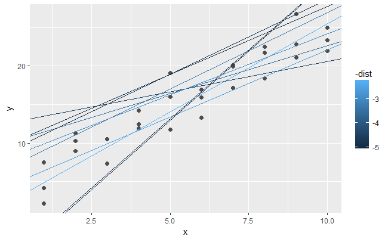

```r
ggplot(sim1, aes(x, y)) +
  geom_point(size = 2, colour = "grey30") +
  geom_abline(
    aes(intercept = a1, slope = a2, colour = -dist),
    data = filter(models, rank(dist) <= 10)
  )
```

- 模型可视化，将 `a1` 、 `a2` 分别作为横纵坐标，用颜色表示模型的拟合程度：

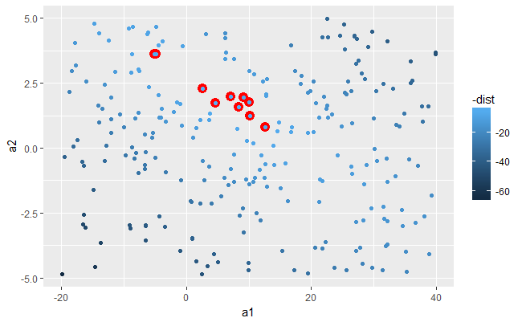

```r
ggplot(models, aes(a1, a2)) +
  geom_point(data = filter(models, rank(dist) <= 10), size = 4, colour = "red") +
  geom_point(aes(colour = -dist))
```

- 生成网格化的参数，寻找拟合程度最好的模型：

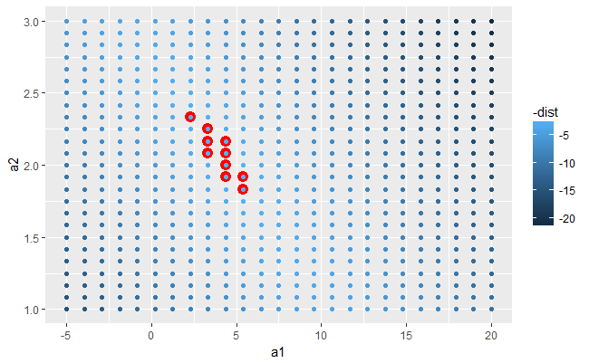

```r
grid <- expand.grid(
  a1 = seq(-5, 20, length = 25),
  a2 = seq(1, 3, length = 25)
  ) %>%
  mutate(dist = purrr::map2_dbl(a1, a2, sim1_dist))
grid %>%
  ggplot(aes(a1, a2)) +
  geom_point(data = filter(grid, rank(dist) <= 10), size = 4, colour = "red") +
  geom_point(aes(colour = -dist))
```

- 在散点图中绘制拟合程度最好的10个模型：

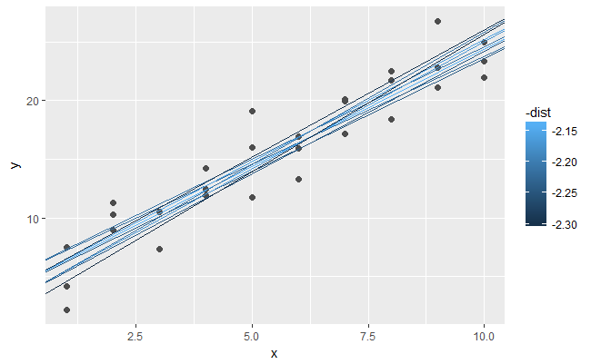

```r
ggplot(sim1, aes(x, y)) +
  geom_point(size = 2, colour = "grey30") +
  geom_abline(
    aes(intercept = a1, slope = a2, colour = -dist),
    data = filter(grid, rank(dist) <= 10)
  )
```

## 2.2 最优化函数 `optim()`

```r
best <- optim(c(0, 0), measure_distance, data = sim1)
best$par
```

```
[1] 4.222248 2.051204
```

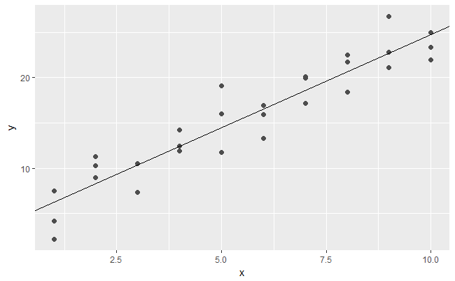

```r
ggplot(sim1, aes(x, y)) +
  geom_point(size = 2, colour = "grey30") +
  geom_abline(intercept = best$par[1], slope = best$par[2])
```

## 2.3 线性回归函数 `lm()`

```r
sim1_mod <- lm(y ~ x, data = sim1)
coef(sim1_mod)
```

```
(Intercept)           x
   4.220822    2.051533
```

# 3 模型可视化

## 3.1 预测

- `modelr::data_grid()` 接收数据集，并对指定变量的唯一值生成所有的组合：

```r
grid <- sim1 %>%
  data_grid(x)
grid
```

| x |
| --- |
| 1 |
| 2 |
| 3 |
| 4 |
| 5 |
| 6 |
| 7 |
| 8 |
| 9 |
| 10 |

```
#> # A tibble: 10 × 1
#>       x
#>   <int>
#> 1     1
#> 2     2
#> 3     3
#> 4     4
#> 5     5
#> 6     6
#> # ... with 4 more rows
```

- `modelr::add_predictions()` 接收数据集和模型，将预测值作为新列添加在数据集中：

```r
grid <- grid %>%
  add_predictions(sim1_mod)
grid
```

| x | pred |
| --- | --- |
| 1 | 6.272355 |
| 2 | 8.323888 |
| 3 | 10.375421 |
| 4 | 12.426954 |
| 5 | 14.478487 |
| 6 | 16.530020 |
| 7 | 18.581553 |
| 8 | 20.633087 |
| 9 | 22.684620 |
| 10 | 24.736153 |

```
#> # A tibble: 10 × 2
#>        x      pred
#>    <int>     <dbl>
#> 1      1  6.272355
#> 2      2  8.323888
#> 3      3 10.375421
#> 4      4 12.426954
#> 5      5 14.478487
#> 6      6 16.530020
#> 7      7 18.581553
#> 8      8 20.633087
#> 9      9 22.684620
#> 10    10 24.736153
```

- `geom_line()` 可视化：

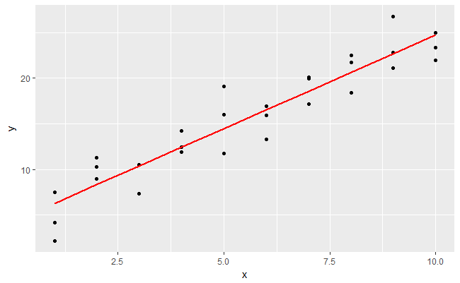

```r
ggplot(sim1, aes(x)) +
  geom_point(aes(y = y)) +
  geom_line(aes(y = pred), data = grid, colour = "red", size = 1)
```

这种 `geom_line()` 与 `add_predictions()` 的合用方法与上节中求出参数后用 `geom_abline()` 相比，优势在于可以应用于 R 中所有的模型。

## 3.2 残差

- `add_residuals()` 接收数据集和模型，将残差作为新列添加在数据集中：

```r
sim1 <- sim1 %>%
  add_residuals(sim1_mod)
sim1
```

| x | y | resid |
| --- | --- | --- |
| 1 | 4.199913 | -2.072442018 |
| 1 | 7.510634 | 1.238279125 |
| 1 | 2.125473 | -4.146882207 |
| 2 | 8.988857 | 0.664969362 |
| 2 | 10.243105 | 1.919217378 |
| 2 | 11.296823 | 2.972935148 |
| 3 | 7.356365 | -3.019056466 |
| 3 | 10.505349 | 0.129928252 |
| 3 | 10.511601 | 0.136179642 |
| 4 | 12.434589 | 0.007634878 |

[output cut: 20 more lines]

```
#> # A tibble: 30 × 3
#>        x         y        resid
#>    <int>     <dbl>        <dbl>
#> 1      1  4.199913 -2.072442018
#> 2      1  7.510634  1.238279125
#> 3      1  2.125473 -4.146882207
#> 4      2  8.988857  0.664969362
#> 5      2 10.243105  1.919217378
#> 6      2 11.296823  2.972935148
#> 7      3  7.356365 -3.019056466
#> 8      3 10.505349  0.129928252
#> 9      3 10.511601  0.136179642
#> 10     4 12.434589  0.007634878
#> # ... with 20 more rows
```

- `geom_freqpoly` 绘制残差频率图：

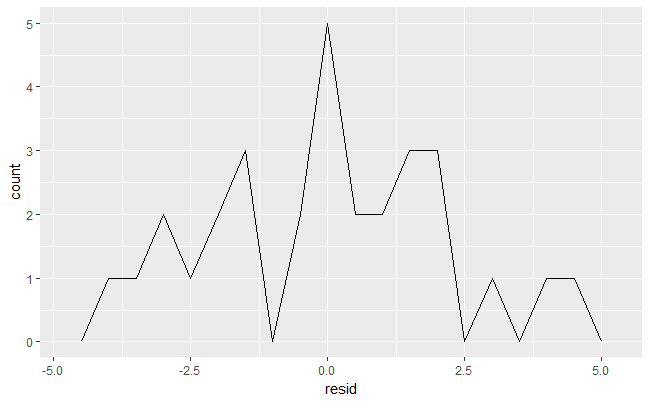

```r
ggplot(sim1, aes(resid)) +
  geom_freqpoly(binwidth = 0.5)
```

- `geom_point()` 绘制残差散点图

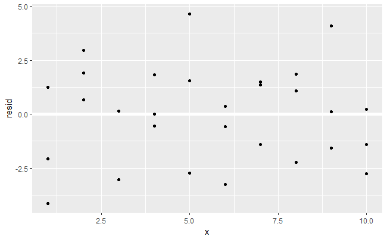

```r
ggplot(sim1, aes(x, resid)) +
  geom_ref_line(h = 0) +
  geom_point()
```

# 4 公式和模型族

`model_matrix()` 函数接受数据集和公式，将数据集处理成模型中所用的 `X` ：

```r
df <- tribble(
  ~y, ~x1, ~x2,
  4, 2, 5,
  5, 1, 6
)
model_matrix(df, y ~ x1)
```

| (Intercept) | x1 |
| --- | --- |
| 1 | 2 |
| 1 | 1 |

```
#> # A tibble: 2 × 2
#>   `(Intercept)`    x1
#>           <dbl> <dbl>
#> 1             1     2
#> 2             1     1
```

`model_matrix()` 会自动添加截距项，在公式中设置 `-1` 可以不显示截距项：

```r
model_matrix(df, y ~ x1 - 1)
```

| x1 |
| --- |
| 2 |
| 1 |

```
#> # A tibble: 2 × 1
#>      x1
#>   <dbl>
#> 1     2
#> 2     1
```

## 4.1 类别变量

`model_matrix()` 会对类别变量进行独热编码：

```r
df <- tribble(
  ~ sex, ~ response,
  "male", 1,
  "female", 2,
  "male", 1
)
model_matrix(df, response ~ sex)
```

| (Intercept) | sexmale |
| --- | --- |
| 1 | 1 |
| 1 | 0 |
| 1 | 1 |

```
#> # A tibble: 3 × 2
#>   `(Intercept)` sexmale
#>           <dbl>   <dbl>
#> 1             1       1
#> 2             1       0
#> 3             1       1
```

`sim2` 数据集中变量 `x` 是类别变量：

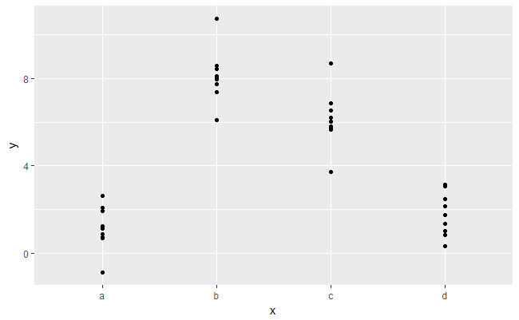

```r
ggplot(sim2) +
  geom_point(aes(x, y))
```

可以对该数据集建立线性模型，并生成预测值：

```r
mod2 <- lm(y ~ x, data = sim2)
grid <- sim2 %>%
  data_grid(x) %>%
  add_predictions(mod2)
grid
```

| x | pred |
| --- | --- |
| a | 1.152166 |
| b | 8.116039 |
| c | 6.127191 |
| d | 1.910981 |

```
#> # A tibble: 4 × 2
#>       x  pred
#>   <chr> <dbl>
#> 1     a  1.15
#> 2     b  8.12
#> 3     c  6.13
#> 4     d  1.91
```

类别变量的线性回归，预测值一定是是条件均值：

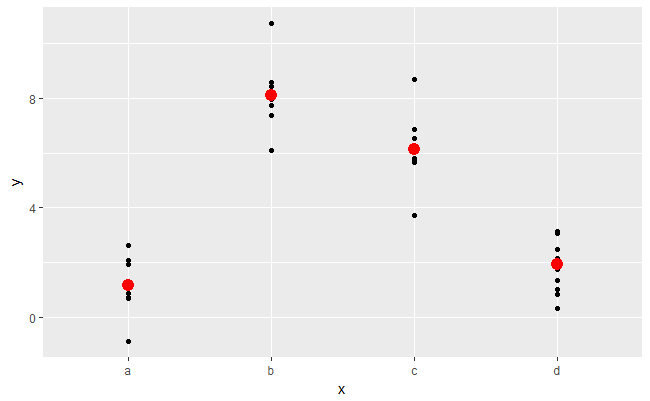

```r
ggplot(sim2, aes(x)) +
  geom_point(aes(y = y)) +
  geom_point(data = grid, aes(y = pred), colour = "red", size = 4)
```

无法对数据集中没有出现过的类别变量取值进行预测：

```r
tibble(x = "e") %>%
  add_predictions(mod2)
```

```
Error in model.frame.default(Terms, newdata, na.action = na.action, xlev = object$xlevels) :
  factor x has new level e
```

## 4.2 交互作用（连续变量和类别变量）

`sim3` 数据集中，变量 `x1` 是连续变量， 变量 `x2` 是类别变量：

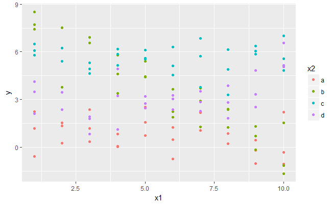

```r
ggplot(sim3, aes(x1, y)) +
  geom_point(aes(colour = x2))
```

对该数据集可以建立两种模型，其中公式 `y ~ x1 * x2` 相当于 `y = a_0 + a_1 * a1 + a_2 * a2 + a_12 * a1 * a2` ，变量和其交互项都会被纳入模型：

```r
mod1 <- lm(y ~ x1 + x2, data = sim3)
mod2 <- lm(y ~ x1 * x2, data = sim3)
```

`gather_predictions()` 可以同时对多个模型生成预测值：

```r
grid <- sim3 %>%
  data_grid(x1, x2) %>%
  gather_predictions(mod1, mod2)
grid
```

| model | x1 | x2 | pred |
| --- | --- | --- | --- |
| mod1 | 1 | a | 1.67492811 |
| mod1 | 1 | b | 4.56273896 |
| mod1 | 1 | c | 6.48066399 |
| mod1 | 1 | d | 4.03451486 |
| mod1 | 2 | a | 1.47819036 |
| mod1 | 2 | b | 4.36600121 |
| mod1 | 2 | c | 6.28392624 |
| mod1 | 2 | d | 3.83777710 |
| mod1 | 3 | a | 1.28145260 |
| mod1 | 3 | b | 4.16926345 |

[output cut: 70 more lines]

```
#> # A tibble: 80 × 4
#>   model    x1     x2  pred
#>   <chr> <int> <fctr> <dbl>
#> 1  mod1     1      a  1.67
#> 2  mod1     1      b  4.56
#> 3  mod1     1      c  6.48
#> 4  mod1     1      d  4.03
#> 5  mod1     2      a  1.48
#> 6  mod1     2      b  4.37
#> # ... with 74 more rows
```

`spread_predictions()` 也可以同时对多个模型生成预测值，每个模型的预测值单独成列：

```r
sim3 %>%
  data_grid(x1, x2) %>%
  spread_predictions(mod1, mod2)
```

| x1 | x2 | mod1 | mod2 |
| --- | --- | --- | --- |
| 1 | a | 1.67492811 | 1.2082182 |
| 1 | b | 4.56273896 | 7.5173128 |
| 1 | c | 6.48066399 | 5.7072663 |
| 1 | d | 4.03451486 | 2.3200486 |
| 2 | a | 1.47819036 | 1.1151938 |
| 2 | b | 4.36600121 | 6.6640031 |
| 2 | c | 6.28392624 | 5.6823947 |
| 2 | d | 3.83777710 | 2.5043033 |
| 3 | a | 1.28145260 | 1.0221693 |
| 3 | b | 4.16926345 | 5.8106934 |

[output cut: 30 more lines]

```
#> # A tibble: 40 × 4
#>       x1     x2     mod1     mod2
#>    <int> <fctr>    <dbl>    <dbl>
#> 1      1      a 1.674928 1.208218
#> 2      1      b 4.562739 7.517313
#> 3      1      c 6.480664 5.707266
#> 4      1      d 4.034515 2.320049
#> 5      2      a 1.478190 1.115194
#> 6      2      b 4.366001 6.664003
#> 7      2      c 6.283926 5.682395
#> 8      2      d 3.837777 2.504303
#> 9      3      a 1.281453 1.022169
#> 10     3      b 4.169263 5.810693
#> # ... with 30 more rows
```

对两个模型进行可视化：

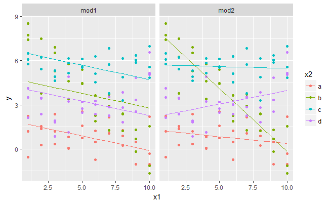

```r
ggplot(sim3, aes(x1, y, colour = x2)) +
  geom_point() +
  geom_line(data = grid, aes(y = pred)) +
  facet_wrap(~ model)
```

对两个模型的残差进行可视化，依据模型和变量 `x2` 进行分面：

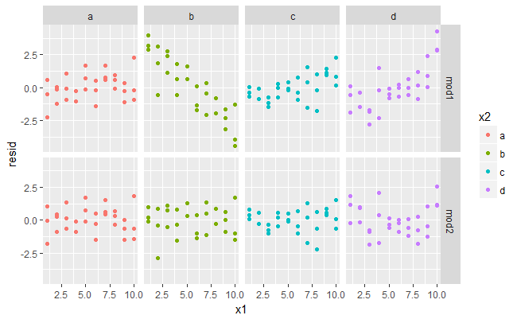

```r
sim3 <- sim3 %>%
  gather_residuals(mod1, mod2)
ggplot(sim3, aes(x1, resid, colour = x2)) +
  geom_point() +
  facet_grid(model ~ x2)
```

从残差图中可以看出， `mod1` 并没有很好地捕捉变量 `b` 的模式。

## 4.3 交互作用（两个连续变量）

`sim4` 数据集中有两个连续变量：

```r
mod1 <- lm(y ~ x1 + x2, data = sim4)
mod2 <- lm(y ~ x1 * x2, data = sim4)
grid <- sim4 %>%
  data_grid(
    x1 = seq_range(x1, 5),
    x2 = seq_range(x2, 5)
  ) %>%
  gather_predictions(mod1, mod2)
grid
```

| model | x1 | x2 | pred |
| --- | --- | --- | --- |
| mod1 | -1.0 | -1.0 | 0.99630938 |
| mod1 | -1.0 | -0.5 | -0.39494837 |
| mod1 | -1.0 | 0.0 | -1.78620613 |
| mod1 | -1.0 | 0.5 | -3.17746388 |
| mod1 | -1.0 | 1.0 | -4.56872164 |
| mod1 | -0.5 | -1.0 | 1.90714243 |
| mod1 | -0.5 | -0.5 | 0.51588467 |
| mod1 | -0.5 | 0.0 | -0.87537308 |
| mod1 | -0.5 | 0.5 | -2.26663084 |
| mod1 | -0.5 | 1.0 | -3.65788859 |

[output cut: 40 more lines]

```
#> # A tibble: 50 × 4
#>   model    x1    x2   pred
#>   <chr> <dbl> <dbl>  <dbl>
#> 1  mod1  -1.0  -1.0  0.996
#> 2  mod1  -1.0  -0.5 -0.395
#> 3  mod1  -1.0   0.0 -1.786
#> 4  mod1  -1.0   0.5 -3.177
#> 5  mod1  -1.0   1.0 -4.569
#> 6  mod1  -0.5  -1.0  1.907
#> # ... with 44 more rows
```

由于两个变量都是连续变量，在 `data_grid()` 中使用了 `seq_range()` 函数，以生成等间距的网格数据。 `seq_range()` 函数有三个重要变量：

- `pretty = TRUE`

```r
seq_range(c(0.0123, 0.923423), n = 5)
```

```
[1] 0.0123000 0.2400808 0.4678615 0.6956423 0.9234230
```

```r
seq_range(c(0.0123, 0.923423), n = 5, pretty = TRUE)
```

```
[1] 0.0 0.2 0.4 0.6 0.8 1.0
```

- `trim = 0.1`

```r
x1 <- rcauchy(100)
```

```r
seq_range(x1, n = 5)
```

```
[1] -43.39208  52.59973 148.59155 244.58336 340.57517
```

```r
seq_range(x1, n = 5, trim = 0.10)
```

```
[1] -5.9447105 -2.7874461  0.3698184  3.5270828  6.6843473
```

```r
seq_range(x1, n = 5, trim = 0.25)
```

```
[1] -1.643226 -0.720693  0.201840  1.124373  2.046906
```

```r
seq_range(x1, n = 5, trim = 0.50)
```

```
[1] -0.7290666 -0.3018332  0.1254003  0.5526337  0.9798672
```

- `expand = 0.1`

```r
x2 <- c(0, 1)
```

```r
seq_range(x2, n = 5)
```

```
[1] 0.00 0.25 0.50 0.75 1.00
```

```r
seq_range(x2, n = 5, expand = 0.10)
```

```
[1] -0.050  0.225  0.500  0.775  1.050
```

```r
seq_range(x2, n = 5, expand = 0.25)
```

```
[1] -0.1250  0.1875  0.5000  0.8125  1.1250
```

```r
seq_range(x2, n = 5, expand = 0.50)
```

```
[1] -0.250  0.125  0.500  0.875  1.250
```

使用 `geom_tile()` 对包含两个连续变量的模型进行可视化：

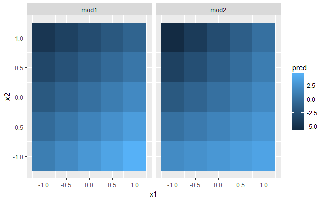

```r
ggplot(grid, aes(x1, x2)) +
  geom_tile(aes(fill = pred)) +
  facet_wrap(~ model)
```

存在交互作用的模型，没有固定不变的斜率：

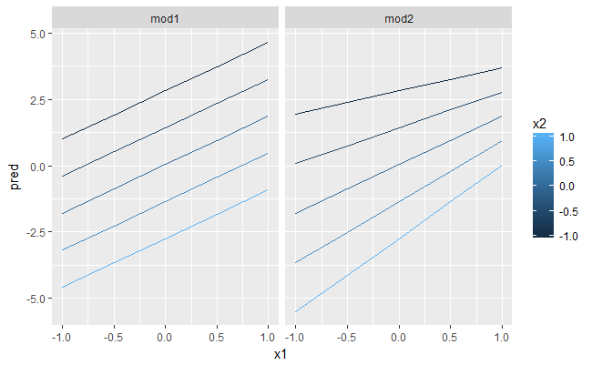

```r
ggplot(grid, aes(x1, pred, colour = x2, group = x2)) +
  geom_line() +
  facet_wrap(~ model)
```

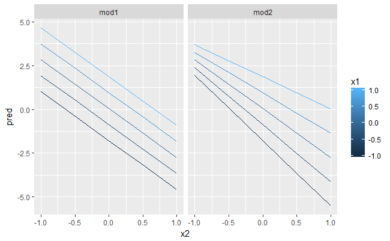

```r
ggplot(grid, aes(x2, pred, colour = x1, group = x1)) +
  geom_line() +
  facet_wrap(~ model)
```

## 4.4 数据转换

不确定公式的含义时，可以使用 `model_matrix()` 来观察 `X` ，从而得知 `lm()` 背后的实际模型：

```r
df <- tribble(
  ~y, ~x,
   1,  1,
   2,  2,
   3,  3
)
model_matrix(df, y ~ x^2 + x)
```

| (Intercept) | x |
| --- | --- |
| 1 | 1 |
| 1 | 2 |
| 1 | 3 |

```
#> # A tibble: 3 × 2
#>   `(Intercept)`     x
#>           <dbl> <dbl>
#> 1             1     1
#> 2             1     2
#> 3             1     3
```

```r
model_matrix(df, y ~ I(x^2) + x)
```

| (Intercept) | I(x^2) | x |
| --- | --- | --- |
| 1 | 1 | 1 |
| 1 | 4 | 2 |
| 1 | 9 | 3 |

```
#> # A tibble: 3 × 3
#>   `(Intercept)` `I(x^2)`     x
#>           <dbl>    <dbl> <dbl>
#> 1             1        1     1
#> 2             1        4     2
#> 3             1        9     3
```

可以使用 `poly()` 快速生成多项式函数，拟合非线性模型：

```r
model_matrix(df, y ~ poly(x, 2))
```

| (Intercept) | poly(x, 2)1 | poly(x, 2)2 |
| --- | --- | --- |
| 1 | -7.071068e-01 | 0.4082483 |
| 1 | -7.850462e-17 | -0.8164966 |
| 1 | 7.071068e-01 | 0.4082483 |

```
#> # A tibble: 3 × 3
#>   `(Intercept)` `poly(x, 2)1` `poly(x, 2)2`
#>           <dbl>         <dbl>         <dbl>
#> 1             1     -7.07e-01         0.408
#> 2             1     -7.85e-17        -0.816
#> 3             1      7.07e-01         0.408
```

使用多项式函数，容易产生过拟合，在训练数据集以外迅速向正负无穷逼近。可以使用 `splines::ns()` ：

```r
library(splines)
```

```r
model_matrix(df, y ~ ns(x, 2))
```

| (Intercept) | ns(x, 2)1 | ns(x, 2)2 |
| --- | --- | --- |
| 1 | 0.0000000 | 0.0000000 |
| 1 | 0.5662628 | -0.2108419 |
| 1 | 0.3440969 | 0.7706021 |

```
#> # A tibble: 3 × 3
#>   `(Intercept)` `ns(x, 2)1` `ns(x, 2)2`
#>           <dbl>       <dbl>       <dbl>
#> 1             1       0.000       0.000
#> 2             1       0.566      -0.211
#> 3             1       0.344       0.771
```

尝试拟合非线性函数：

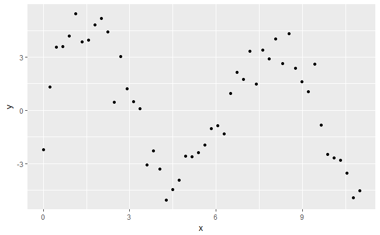

```r
sim5 <- tibble(
  x = seq(0, 3.5 * pi, length = 50),
  y = 4 * sin(x) + rnorm(length(x))
)
ggplot(sim5, aes(x, y)) +
  geom_point()
```

建立5种模型：

```r
mod1 <- lm(y ~ ns(x, 1), data = sim5)
mod2 <- lm(y ~ ns(x, 2), data = sim5)
mod3 <- lm(y ~ ns(x, 3), data = sim5)
mod4 <- lm(y ~ ns(x, 4), data = sim5)
mod5 <- lm(y ~ ns(x, 5), data = sim5)
```

分别可视化5种模型：

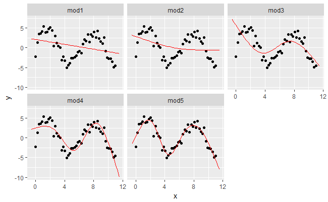

```r
grid <- sim5 %>%
  data_grid(x = seq_range(x, n = 50, expand = 0.1)) %>%
  gather_predictions(mod1, mod2, mod3, mod4, mod5, .pred = "y")
ggplot(sim5, aes(x, y)) +
  geom_point() +
  geom_line(data = grid, colour = "red") +
  facet_wrap(~ model)
```

# 5 缺失值

在建模时， `R` 会自动丢弃存在缺失值的行，且不给出 warning 。但由于在前提准备中设置了 `options(na.action = na.warn)` ，所以会得到 warning ：

```r
df <- tribble(
  ~x, ~y,
  1, 2.2,
  2, NA,
  3, 3.5,
  4, 8.3,
  NA, 10
)
mod <- lm(y ~ x, data = df)
```

```
Dropping 2 rows with missing values
```

设置 `na.action = na.exclude` 可以禁用 warning ：

```r
mod <- lm(y ~ x, data = df, na.action = na.exclude)
```

使用 `nobs()` 查看模型中有多少观测：

```r
nobs(mod)
```

```
[1] 3
```

# 6 其他模型族

- **Generalised linear models**, e.g. `stats::glm()`. Linear models assume that the response is continuous and the error has a normal distribution. Generalised linear models extend linear models to include non-continuous responses (e.g. binary data or counts). They work by defining a distance metric based on the statistical idea of likelihood.
- **Generalised additive models**, e.g. `mgcv::gam()`, extend generalised linear models to incorporate arbitrary smooth functions. That means you can write a formula like `y ~ s(x)` which becomes an equation like `y = f(x)` and let `gam()` estimate what that function is (subject to some smoothness constraints to make the problem tractable).
- **Penalised linear models**, e.g. `glmnet::glmnet()`, add a penalty term to the distance that penalises complex models (as defined by the distance between the parameter vector and the origin). This tends to make models that generalise better to new datasets from the same population.
- **Robust linear models**, e.g. `MASS:rlm()`, tweak the distance to downweight points that are very far away. This makes them less sensitive to the presence of outliers, at the cost of being not quite as good when there are no outliers.
- **Trees**, e.g. `rpart::rpart()`, attack the problem in a completely different way than linear models. They fit a piece-wise constant model, splitting the data into progressively smaller and smaller pieces. Trees aren’t terribly effective by themselves, but they are very powerful when used in aggregate by models like **random forests** (e.g. `randomForest::randomForest()`) or **gradient boosting machines** (e.g. `xgboost::xgboost`.)